# 19 - Time series analysis

Francisco E. Fonturbel

02/November/2025

## A very basic introduction to Time series analysis (TSA)

When we measure the same variable (whichever it is) many times in different times (e.g., daily temperature, monthly moth abundance, yearly inflation) we can build a times series dataset, allowing to conduct very interesting analyses. With TSA we can assess trends without the noise of temporal variation (e.g., seasons) in our data, and therefore making more robust inferences.

```r
#Loading required packages
library(TSA)
library(forecast)
library(astsa)
library(ggplot2)
library(dplyr)
library(tidyr)

#Loading work data
data<-read.table("data/19_bird_data.txt", header=T)
attach(data)
names(data)
```

```
##  [1] "year"    "month"   "aphspiC" "aphspiN" "carbarC" "carbarN" "elaalbC"
##  [8] "elaalbN" "phrpatC" "phrpatN" "troaedC" "troaedN" "turfalC" "turfalN"
## [15] "zoncapC" "zoncapN"
```

```r
# Quick data exploration
str(data)
```

```
## 'data.frame':    156 obs. of  16 variables:
##  $ year   : int  2003 2003 2003 2003 2003 2003 2003 2003 2003 2003 ...
##  $ month  : chr  "jan" "feb" "mar" "apr" ...
##  $ aphspiC: num  7.09 2.52 3.94 5.17 2.66 ...
##  $ aphspiN: num  6.11 1.02 1.87 2.42 0 ...
##  $ carbarC: num  0 0 0 0 0 0 0 0 0 0 ...
##  $ carbarN: num  0 0 0 0 0 0 0 0 0 0 ...
##  $ elaalbC: num  4.049 0.842 0.563 0 0 ...
##  $ elaalbN: num  36.63 0 0.625 0 0 ...
##  $ phrpatC: num  0 5.89 0 3.1 3.1 ...
##  $ phrpatN: num  0 4.09 0 1.45 17.36 ...
##  $ troaedC: num  1.01 0 0 0 0 ...
##  $ troaedN: num  0 0 0 0 0 ...
##  $ turfalC: num  0 0 0 0 0 ...
##  $ turfalN: num  0 1.02 1.25 0 0 ...
##  $ zoncapC: num  1.012 0.842 0 0 0 ...
##  $ zoncapN: num  0 0 0.625 0 0 ...
```

```r
summary(data)
```

```
##       year         month              aphspiC          aphspiN
##  Min.   :2003   Length:156         Min.   : 0.000   Min.   : 0.0000
##  1st Qu.:2006   Class :character   1st Qu.: 1.370   1st Qu.: 0.5151
##  Median :2009   Mode  :character   Median : 2.544   Median : 1.1853
##  Mean   :2009                      Mean   : 3.595   Mean   : 2.1799
##  3rd Qu.:2012                      3rd Qu.: 5.391   3rd Qu.: 2.7037
##  Max.   :2015                      Max.   :14.764   Max.   :18.0046
##     carbarC           carbarN           elaalbC          elaalbN
##  Min.   : 0.0000   Min.   : 0.0000   Min.   :0.0000   Min.   : 0.000
##  1st Qu.: 0.0000   1st Qu.: 0.0000   1st Qu.:0.0000   1st Qu.: 0.000
##  Median : 0.0000   Median : 0.0000   Median :0.0000   Median : 0.000
##  Mean   : 0.2762   Mean   : 0.4141   Mean   :0.7831   Mean   : 2.047
##  3rd Qu.: 0.0000   3rd Qu.: 0.2242   3rd Qu.:1.0145   3rd Qu.: 2.816
##  Max.   :11.0579   Max.   :17.6010   Max.   :6.1094   Max.   :36.630
##     phrpatC           phrpatN          troaedC          troaedN
##  Min.   : 0.0000   Min.   : 0.000   Min.   :0.0000   Min.   :0.0000
##  1st Qu.: 0.3286   1st Qu.: 1.760   1st Qu.:0.0000   1st Qu.:0.0000
##  Median : 0.9255   Median : 4.389   Median :0.0000   Median :0.0000
##  Mean   : 1.9896   Mean   : 7.623   Mean   :0.2811   Mean   :0.4760
##  3rd Qu.: 2.3971   3rd Qu.:10.385   3rd Qu.:0.2289   3rd Qu.:0.5715
##  Max.   :24.1589   Max.   :51.993   Max.   :4.9062   Max.   :5.3749
##     turfalC          turfalN          zoncapC          zoncapN
##  Min.   :0.0000   Min.   :0.0000   Min.   :0.0000   Min.   :0.0000
##  1st Qu.:0.0000   1st Qu.:0.0000   1st Qu.:0.0000   1st Qu.:0.0000
##  Median :0.0000   Median :0.0000   Median :0.0000   Median :0.0000
##  Mean   :0.2327   Mean   :0.2362   Mean   :0.2746   Mean   :0.4386
##  3rd Qu.:0.4565   3rd Qu.:0.2647   3rd Qu.:0.2195   3rd Qu.:0.6060
##  Max.   :1.4245   Max.   :6.0442   Max.   :5.3523   Max.   :2.9586
```

First, we need to convert each variable into a TSA object:

```r
aphcan<-ts(aphspiC, start=c(2003, 1), end=c(2015, 12), frequency=12)
aphnot<-ts(aphspiN, start=c(2003, 1), end=c(2015, 12), frequency=12)
carcan<-ts(carbarC, start=c(2003, 1), end=c(2015, 12), frequency=12)
carnot<-ts(carbarN, start=c(2003, 1), end=c(2015, 12), frequency=12)
elacan<-ts(elaalbC, start=c(2003, 1), end=c(2015, 12), frequency=12)
elanot<-ts(elaalbN, start=c(2003, 1), end=c(2015, 12), frequency=12)
phrcan<-ts(phrpatC, start=c(2003, 1), end=c(2015, 12), frequency=12)
phrnot<-ts(phrpatN, start=c(2003, 1), end=c(2015, 12), frequency=12)
trocan<-ts(troaedC, start=c(2003, 1), end=c(2015, 12), frequency=12)
tronot<-ts(troaedN, start=c(2003, 1), end=c(2015, 12), frequency=12)
turcan<-ts(turfalC, start=c(2003, 1), end=c(2015, 12), frequency=12)
turnot<-ts(turfalN, start=c(2003, 1), end=c(2015, 12), frequency=12)
zoncan<-ts(zoncapC, start=c(2003, 1), end=c(2015, 12), frequency=12)
zonnot<-ts(zoncapN, start=c(2003, 1), end=c(2015, 12), frequency=12)
```

Now that we have those objects, we can plot each variable:

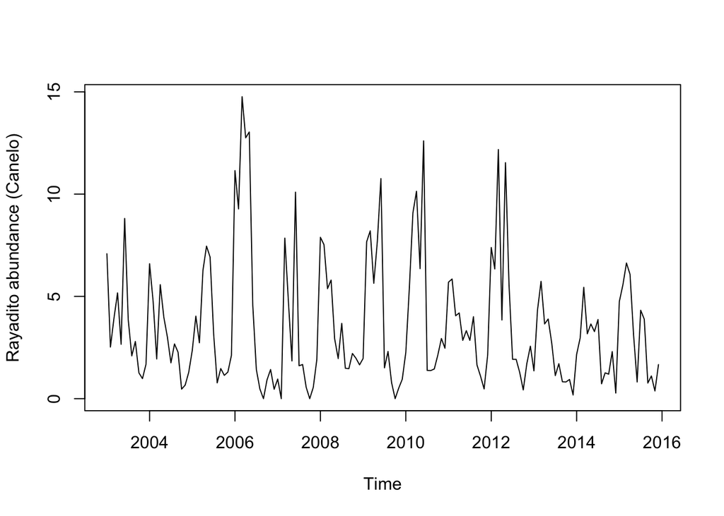

```r
plot(aphcan,ylab='Rayadito abundance (Canelo)')
```

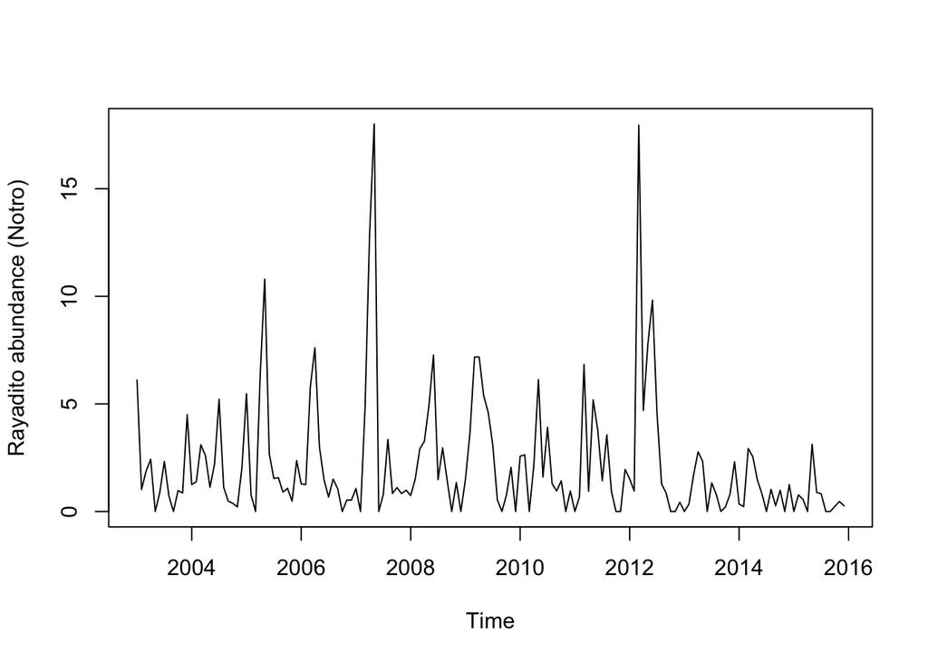

```r
plot(aphnot,ylab='Rayadito abundance (Notro)')
```

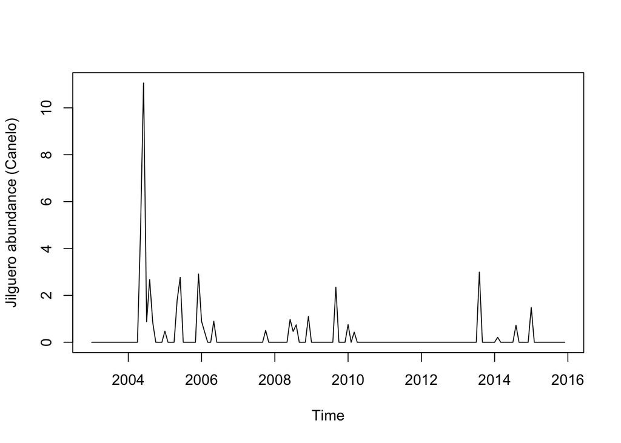

```r
plot(carcan,ylab='Jilguero abundance (Canelo)')
```

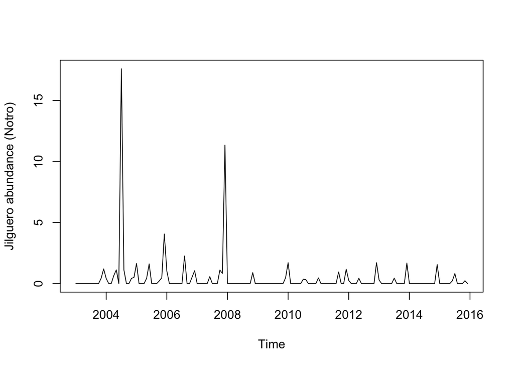

```r
plot(carnot,ylab='Jilguero abundance (Notro)')
```

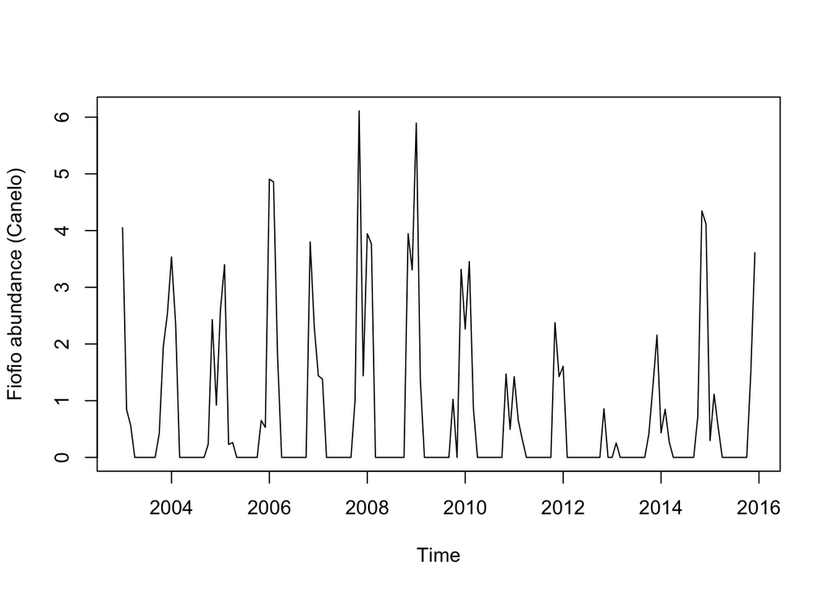

```r
plot(elacan,ylab='Fiofio abundance (Canelo)')
```

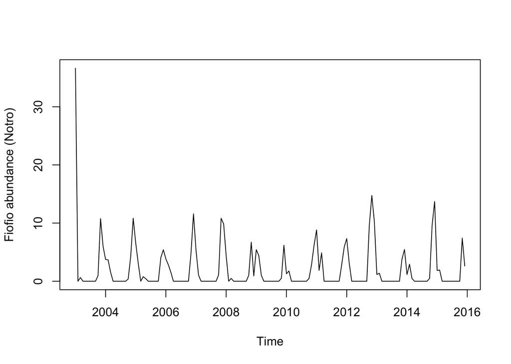

```r
plot(elanot,ylab='Fiofio abundance (Notro)')
```

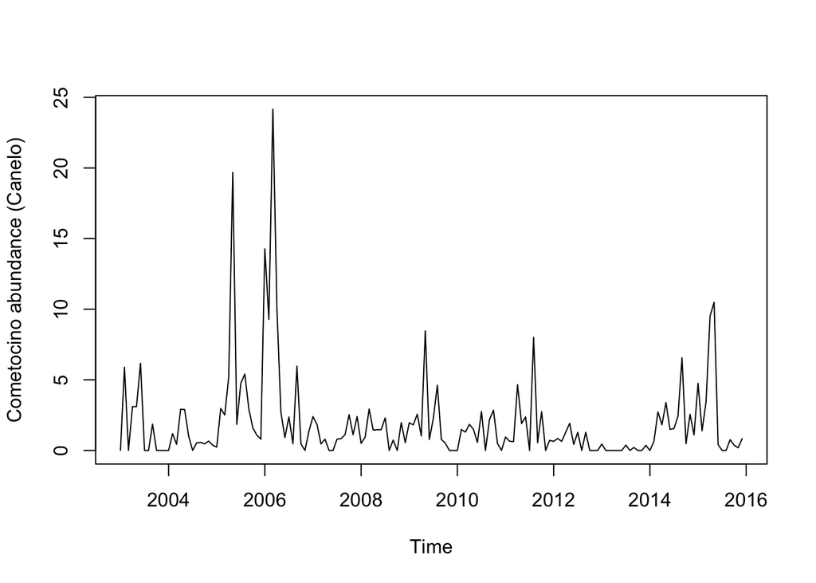

```r
plot(phrcan,ylab='Cometocino abundance (Canelo)')
```

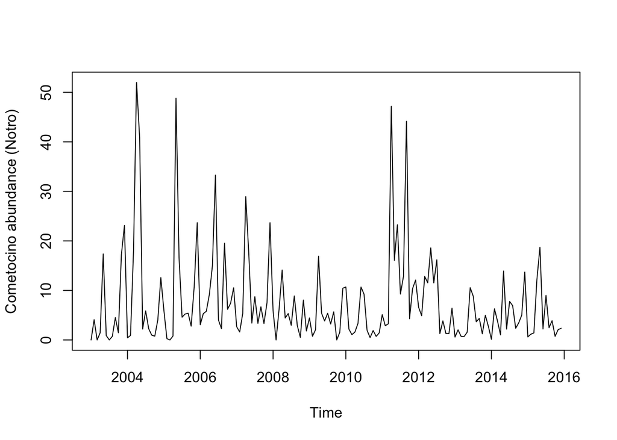

```r
plot(phrnot,ylab='Cometocino abundance (Notro)')
```

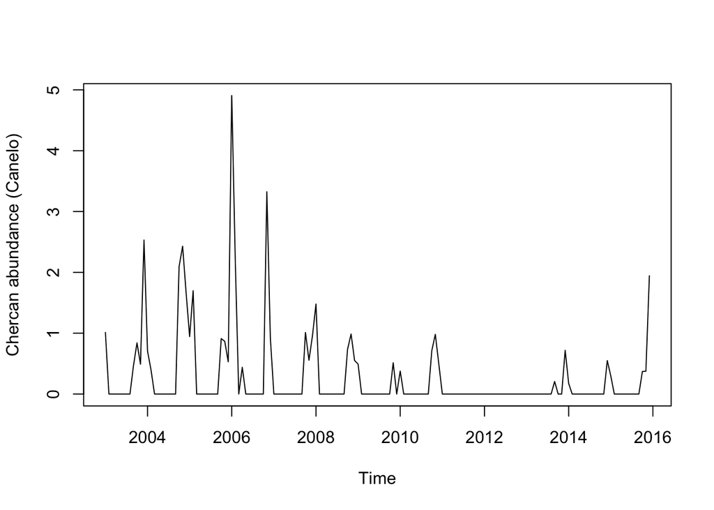

```r
plot(trocan,ylab='Chercan abundance (Canelo)')
```

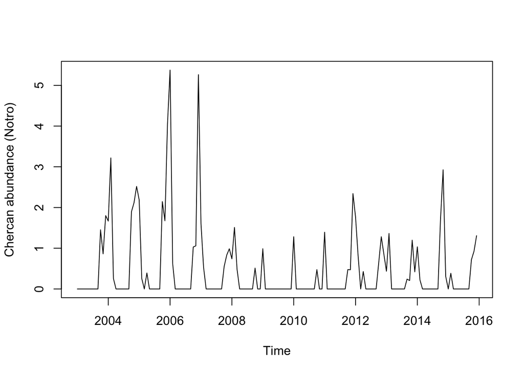

```r
plot(tronot,ylab='Chercan abundance (Notro)')
```

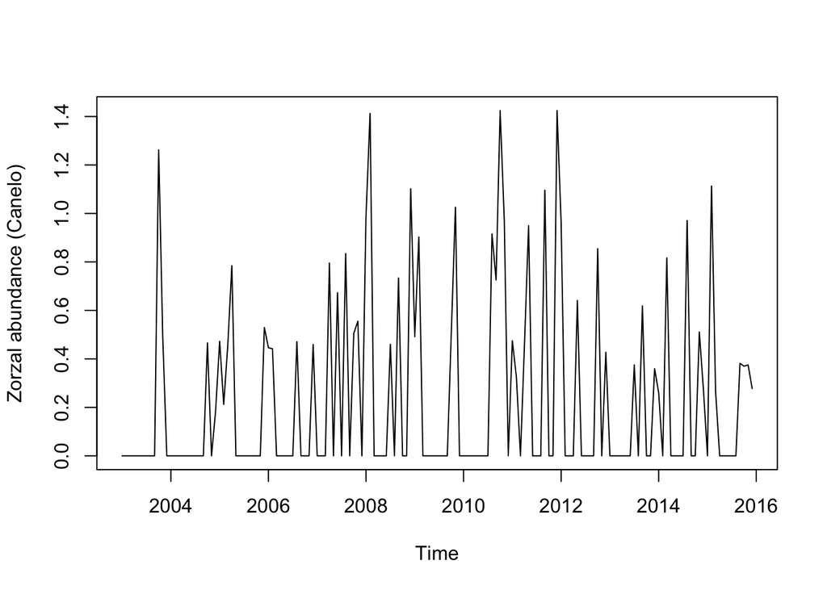

```r
plot(turcan,ylab='Zorzal abundance (Canelo)')
```

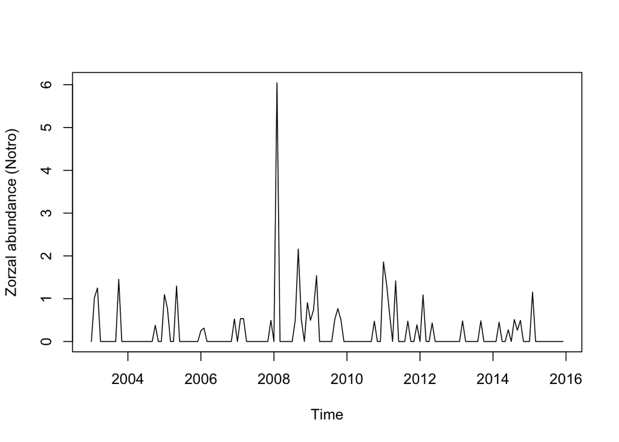

```r
plot(turnot,ylab='Zorzal abundance (Notro)')
```

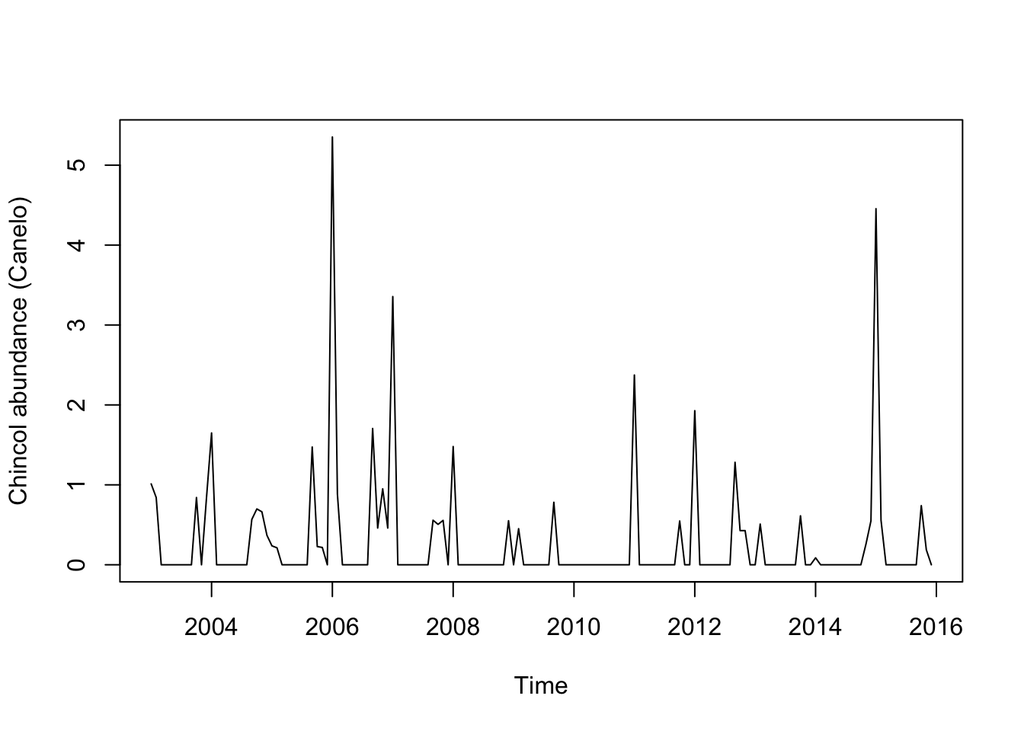

```r
plot(zoncan,ylab='Chincol abundance (Canelo)')
```

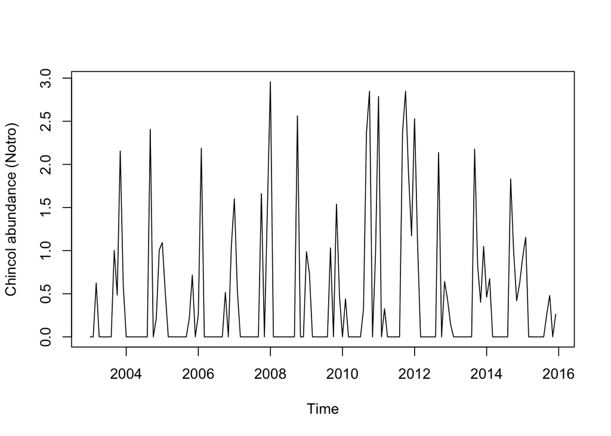

```r
plot(zonnot,ylab='Chincol abundance (Notro)')
```

Holy Molly! a lot of data! Let’s unify habitat data by species:

```r
aphspi<-cbind(aphspiC,aphspiN)
carbar<-cbind(carbarC,carbarN)
elaalb<-cbind(elaalbC,elaalbN)
phrpat<-cbind(phrpatC,phrpatN)
troaed<-cbind(troaedC,troaedN)
turfal<-cbind(turfalC,turfalN)
zoncap<-cbind(zoncapC,zoncapN)
```

And convert them in TSA objects:

```r
rayadito<-ts(aphspi, start=c(2003, 1), end=c(2015, 12), frequency=12)
jilguero<-ts(carbar, start=c(2003, 1), end=c(2015, 12), frequency=12)
fiofio<-ts(elaalb, start=c(2003, 1), end=c(2015, 12), frequency=12)
cometocino<-ts(phrpat, start=c(2003, 1), end=c(2015, 12), frequency=12)
chercan<-ts(troaed, start=c(2003, 1), end=c(2015, 12), frequency=12)
zorzal<-ts(turfal, start=c(2003, 1), end=c(2015, 12), frequency=12)
chincol<-ts(zoncap, start=c(2003, 1), end=c(2015, 12), frequency=12)
```

And plot them again:

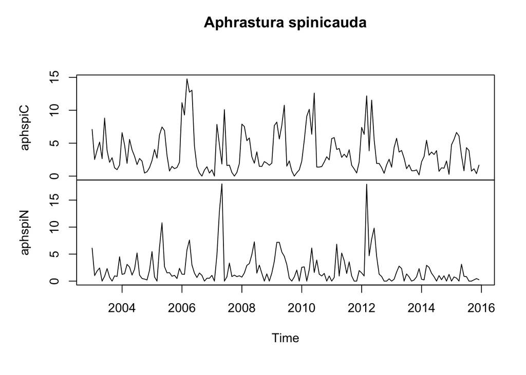

```r
plot(rayadito, main="Aphrastura spinicauda")
```

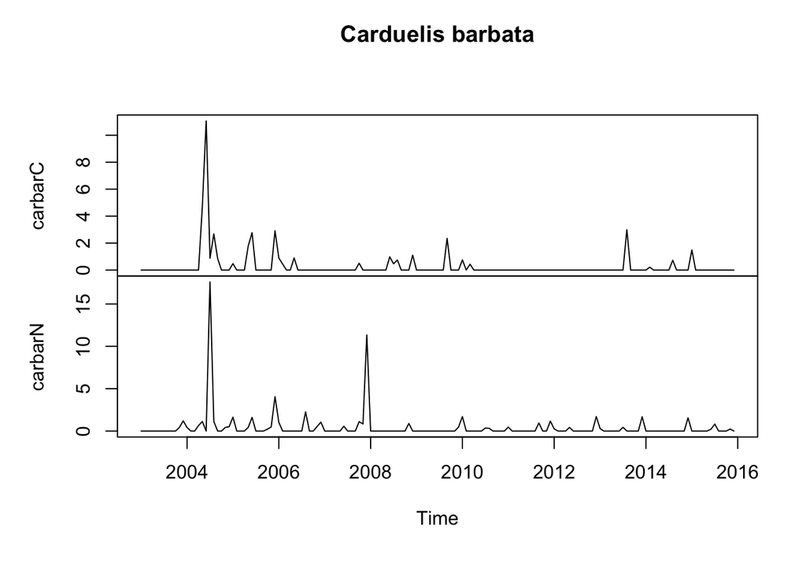

```r
plot(jilguero, main="Carduelis barbata")
```

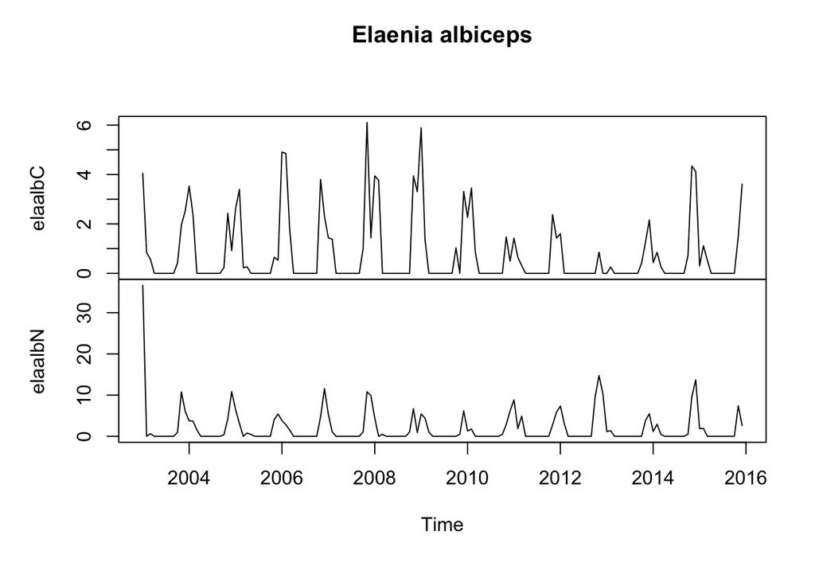

```r
plot(fiofio, main="Elaenia albiceps")
```

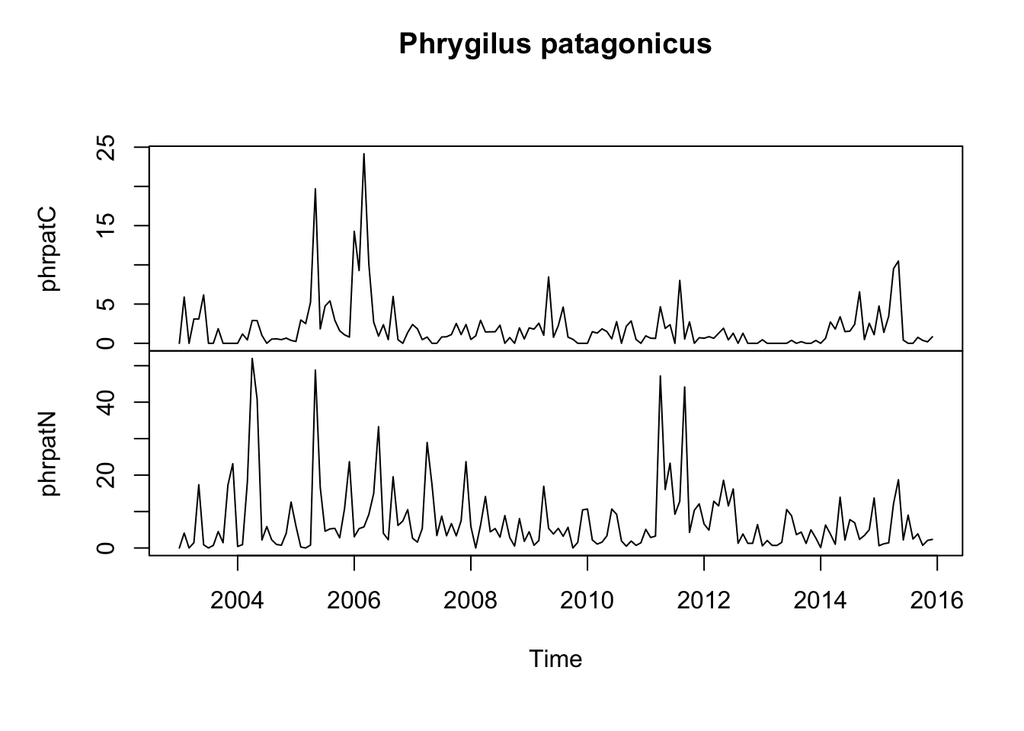

```r
plot(cometocino, main="Phrygilus patagonicus")
```

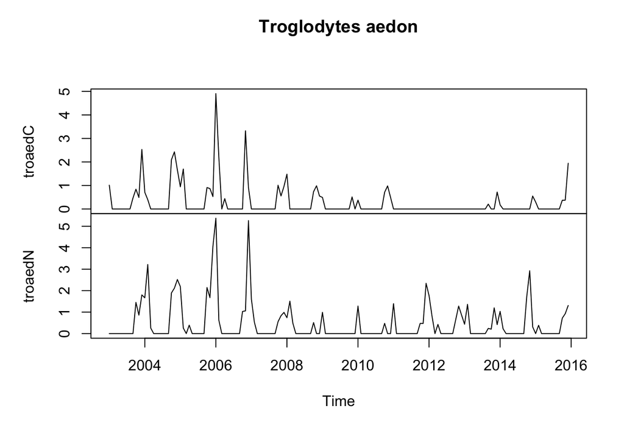

```r
plot(chercan, main="Troglodytes aedon")
```

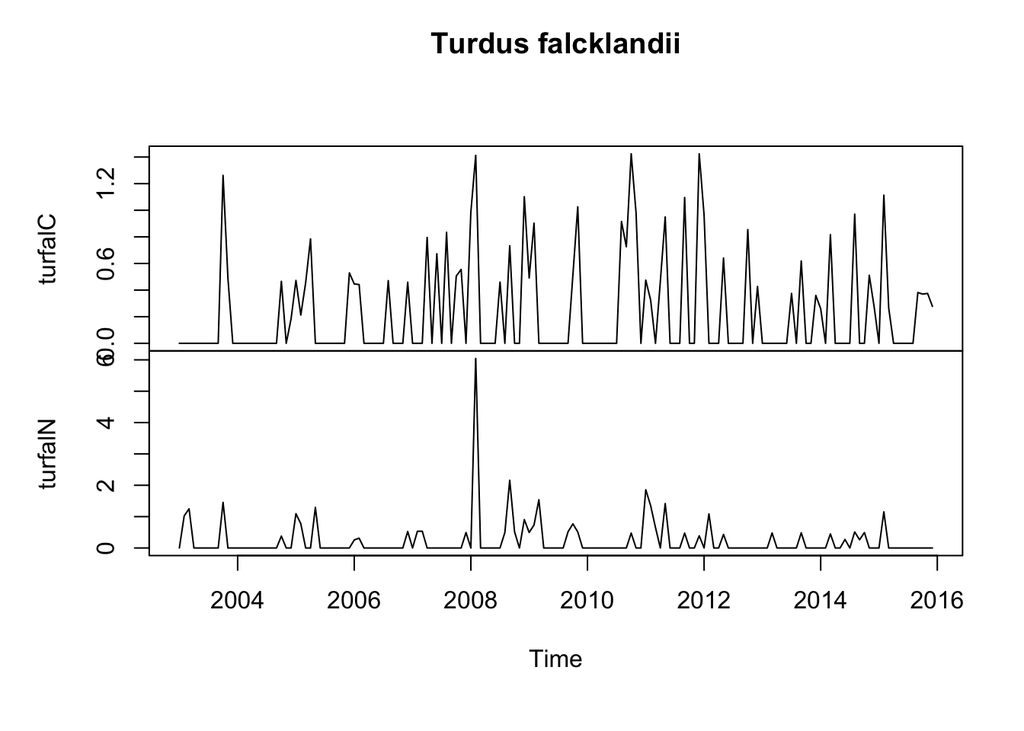

```r
plot(zorzal, main="Turdus falcklandii")
```

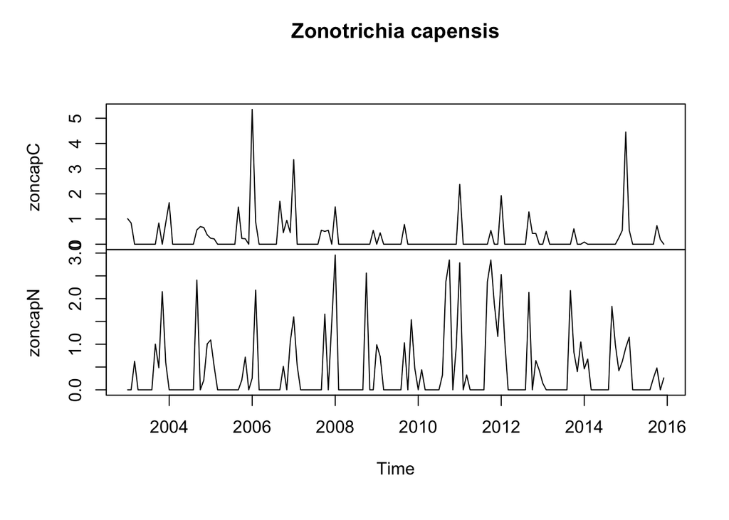

```r
plot(chincol, main="Zonotrichia capensis")
```

## Autocorrelation functions

As we dealt with spatial autocorrelation on lesson 15, in TSA we will deal with temporal autocorrelation, that has the same principle (the shorter the measurement interval, the more similar a variable would be). In this case, we will estimate the autocorrelation function (ACF) for each variable:

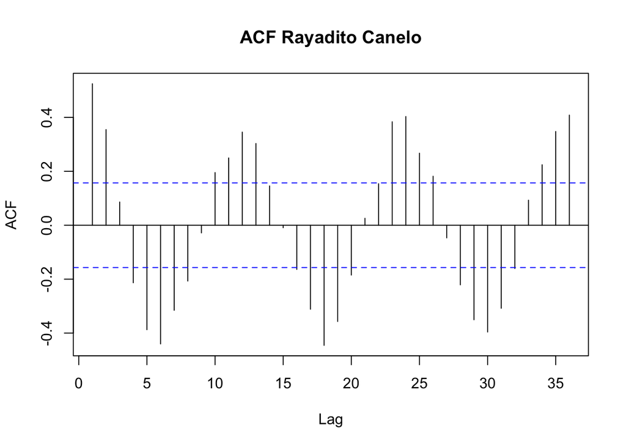

```r
acf(as.vector(aphcan),lag.max=36, main="ACF Rayadito Canelo")
```

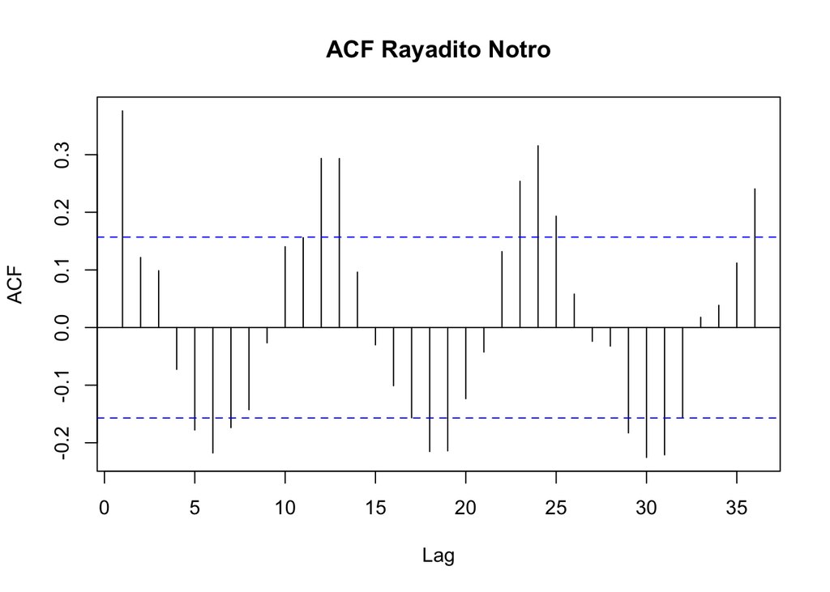

```r
acf(as.vector(aphnot),lag.max=36, main="ACF Rayadito Notro")
```

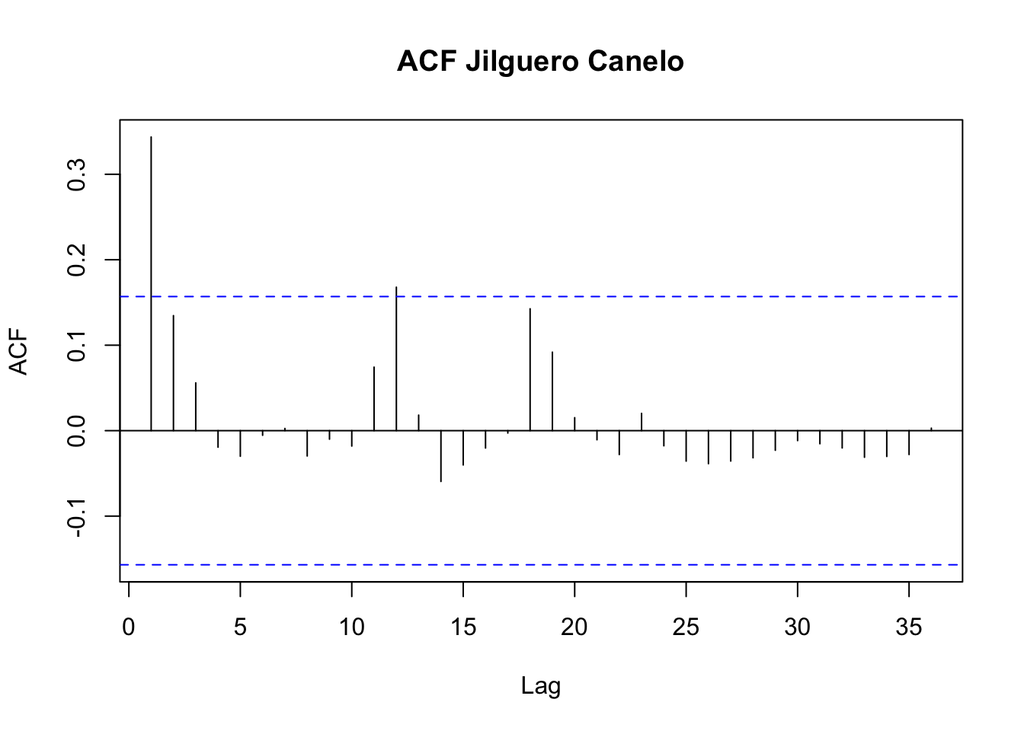

```r
acf(as.vector(carcan),lag.max=36, main="ACF Jilguero Canelo")
```

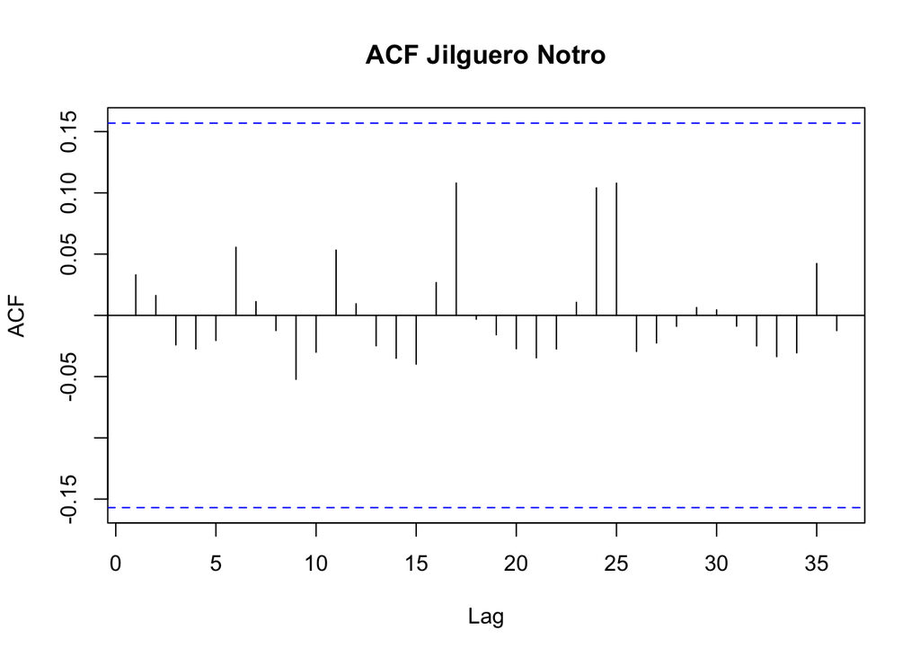

```r
acf(as.vector(carnot),lag.max=36, main="ACF Jilguero Notro")
```

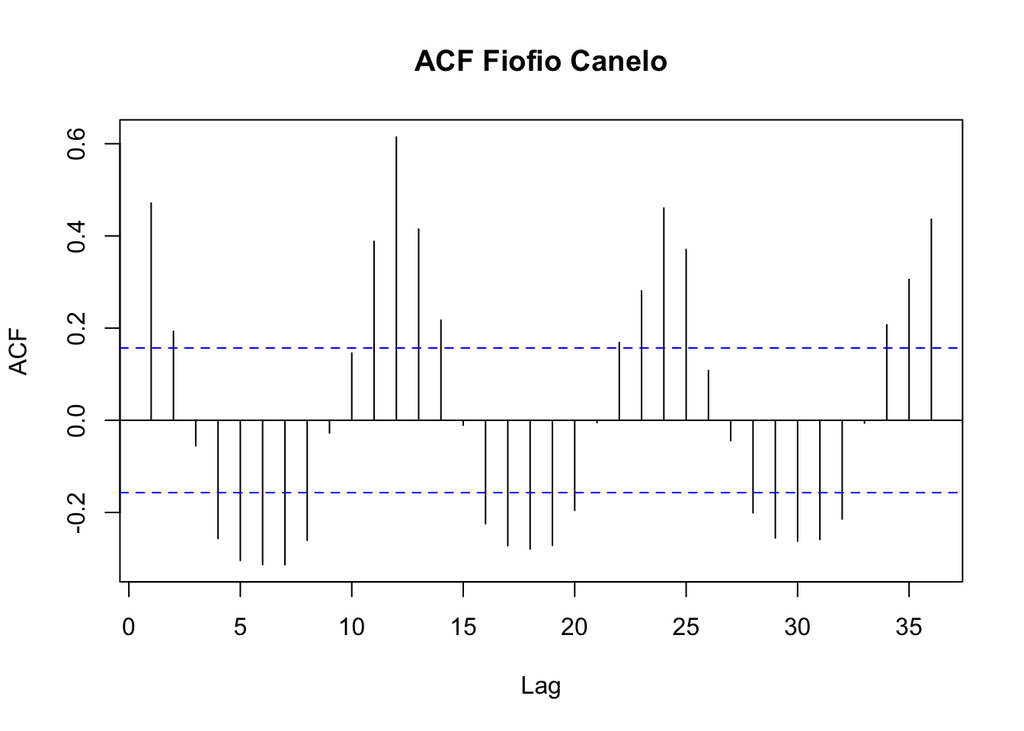

```r
acf(as.vector(elacan),lag.max=36, main="ACF Fiofio Canelo")
```

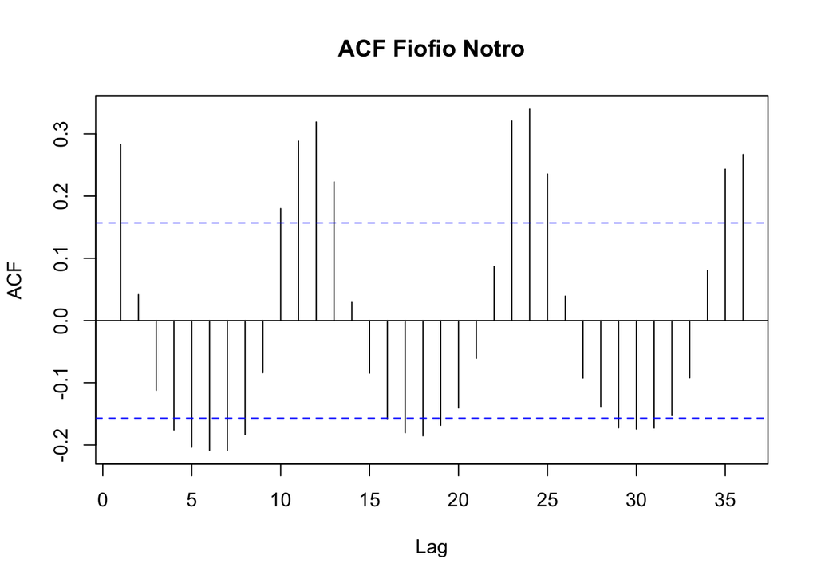

```r
acf(as.vector(elanot),lag.max=36, main="ACF Fiofio Notro")
```

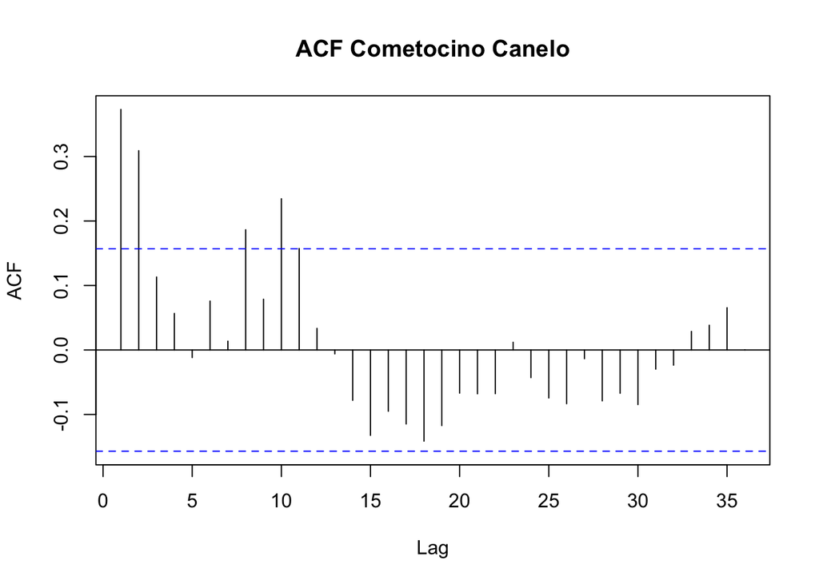

```r
acf(as.vector(phrcan),lag.max=36, main="ACF Cometocino Canelo")
```

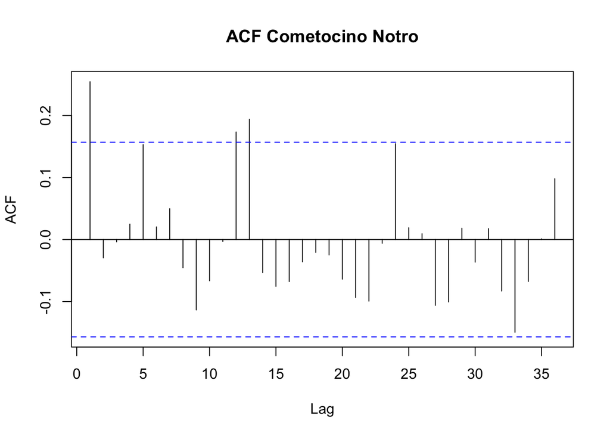

```r
acf(as.vector(phrnot),lag.max=36, main="ACF Cometocino Notro")
```

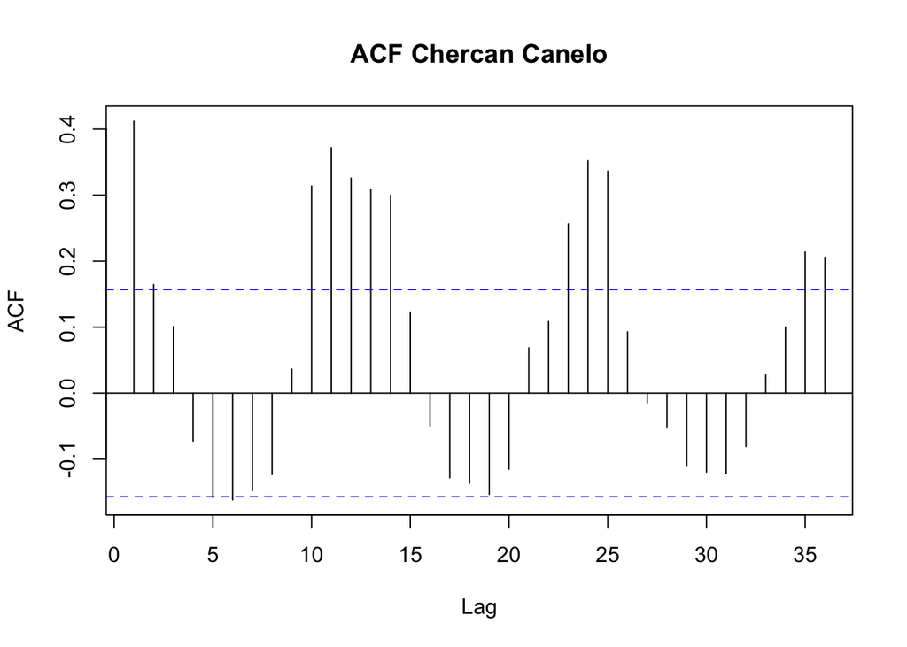

```r
acf(as.vector(trocan),lag.max=36, main="ACF Chercan Canelo")
```

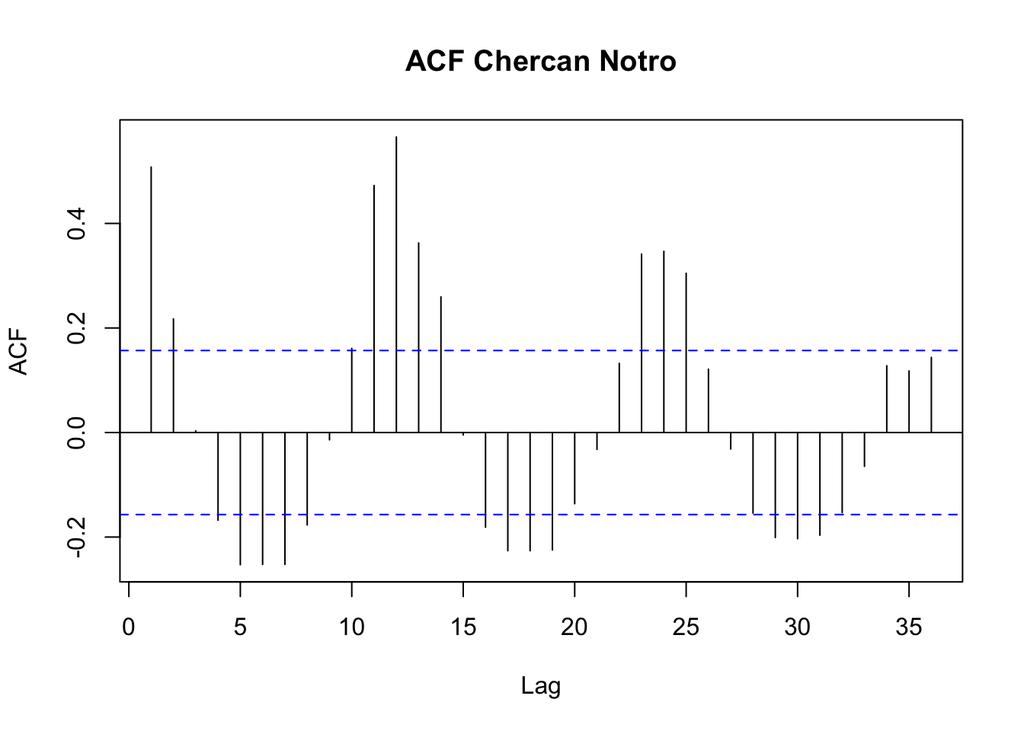

```r
acf(as.vector(tronot),lag.max=36, main="ACF Chercan Notro")
```

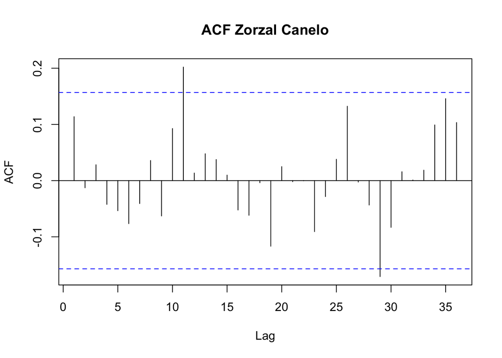

```r
acf(as.vector(turcan),lag.max=36, main="ACF Zorzal Canelo")
```